# Simple data reading and analysis functionalities

Anton Antonov

November 2016

## Introduction

This document illustrates the use of base R functions for data reading and rudimentary data analysis.

## Data summary

Let us read a dataset provided with R’s base system and print its summary:

```r
data("attitude")
summary(attitude)
```

```
##      rating        complaints     privileges       learning
##  Min.   :40.00   Min.   :37.0   Min.   :30.00   Min.   :34.00
##  1st Qu.:58.75   1st Qu.:58.5   1st Qu.:45.00   1st Qu.:47.00
##  Median :65.50   Median :65.0   Median :51.50   Median :56.50
##  Mean   :64.63   Mean   :66.6   Mean   :53.13   Mean   :56.37
##  3rd Qu.:71.75   3rd Qu.:77.0   3rd Qu.:62.50   3rd Qu.:66.75
##  Max.   :85.00   Max.   :90.0   Max.   :83.00   Max.   :75.00
##      raises         critical        advance
##  Min.   :43.00   Min.   :49.00   Min.   :25.00
##  1st Qu.:58.25   1st Qu.:69.25   1st Qu.:35.00
##  Median :63.50   Median :77.50   Median :41.00
##  Mean   :64.63   Mean   :74.77   Mean   :42.93
##  3rd Qu.:71.00   3rd Qu.:80.00   3rd Qu.:47.75
##  Max.   :88.00   Max.   :92.00   Max.   :72.00
```

In some cases we get not very useful results if some of the variables are with strings values:

```r
library(titanic)
summary(titanic_train)
```

```
##   PassengerId       Survived          Pclass          Name
##  Min.   :  1.0   Min.   :0.0000   Min.   :1.000   Length:891
##  1st Qu.:223.5   1st Qu.:0.0000   1st Qu.:2.000   Class :character
##  Median :446.0   Median :0.0000   Median :3.000   Mode  :character
##  Mean   :446.0   Mean   :0.3838   Mean   :2.309
##  3rd Qu.:668.5   3rd Qu.:1.0000   3rd Qu.:3.000
##  Max.   :891.0   Max.   :1.0000   Max.   :3.000
##
##      Sex                 Age            SibSp           Parch
##  Length:891         Min.   : 0.42   Min.   :0.000   Min.   :0.0000
##  Class :character   1st Qu.:20.12   1st Qu.:0.000   1st Qu.:0.0000
##  Mode  :character   Median :28.00   Median :0.000   Median :0.0000
##                     Mean   :29.70   Mean   :0.523   Mean   :0.3816
##                     3rd Qu.:38.00   3rd Qu.:1.000   3rd Qu.:0.0000
##                     Max.   :80.00   Max.   :8.000   Max.   :6.0000
##                     NA's   :177
##     Ticket               Fare           Cabin             Embarked
##  Length:891         Min.   :  0.00   Length:891         Length:891
##  Class :character   1st Qu.:  7.91   Class :character   Class :character
##  Mode  :character   Median : 14.45   Mode  :character   Mode  :character
##                     Mean   : 32.20
##                     3rd Qu.: 31.00
##                     Max.   :512.33
##
```

For these situations we can convert the string valued variables into factors and call `summary` again:

```r
summary(as.data.frame(unclass(titanic_train)))
```

```
##   PassengerId       Survived          Pclass
##  Min.   :  1.0   Min.   :0.0000   Min.   :1.000
##  1st Qu.:223.5   1st Qu.:0.0000   1st Qu.:2.000
##  Median :446.0   Median :0.0000   Median :3.000
##  Mean   :446.0   Mean   :0.3838   Mean   :2.309
##  3rd Qu.:668.5   3rd Qu.:1.0000   3rd Qu.:3.000
##  Max.   :891.0   Max.   :1.0000   Max.   :3.000
##
##                                     Name         Sex           Age
##  Abbing, Mr. Anthony                  :  1   female:314   Min.   : 0.42
##  Abbott, Mr. Rossmore Edward          :  1   male  :577   1st Qu.:20.12
##  Abbott, Mrs. Stanton (Rosa Hunt)     :  1                Median :28.00
##  Abelson, Mr. Samuel                  :  1                Mean   :29.70
##  Abelson, Mrs. Samuel (Hannah Wizosky):  1                3rd Qu.:38.00
##  Adahl, Mr. Mauritz Nils Martin       :  1                Max.   :80.00
##  (Other)                              :885                NA's   :177
##      SibSp           Parch             Ticket         Fare
##  Min.   :0.000   Min.   :0.0000   1601    :  7   Min.   :  0.00
##  1st Qu.:0.000   1st Qu.:0.0000   347082  :  7   1st Qu.:  7.91
##  Median :0.000   Median :0.0000   CA. 2343:  7   Median : 14.45
##  Mean   :0.523   Mean   :0.3816   3101295 :  6   Mean   : 32.20
##  3rd Qu.:1.000   3rd Qu.:0.0000   347088  :  6   3rd Qu.: 31.00
##  Max.   :8.000   Max.   :6.0000   CA 2144 :  6   Max.   :512.33
##                                   (Other) :852
##          Cabin     Embarked
##             :687    :  2
##  B96 B98    :  4   C:168
##  C23 C25 C27:  4   Q: 77
##  G6         :  4   S:644
##  C22 C26    :  3
##  D          :  3
##  (Other)    :186
```

Let us combine the training and testing data from the “titanic” package into one data frame:

```r
commonColNames <- intersect(names(titanic_train), names(titanic_test) )
titanicAll <- rbind( titanic_train[, commonColNames], titanic_test[, commonColNames])
cat("dim(titanicAll) = ", dim(titanicAll), "\n" )
```

```
## dim(titanicAll) =  1309 11
```

```r
summary(as.data.frame(unclass(titanicAll)))
```

```
##   PassengerId       Pclass                                    Name
##  Min.   :   1   Min.   :1.000   Connolly, Miss. Kate            :   2
##  1st Qu.: 328   1st Qu.:2.000   Kelly, Mr. James                :   2
##  Median : 655   Median :3.000   Abbing, Mr. Anthony             :   1
##  Mean   : 655   Mean   :2.295   Abbott, Master. Eugene Joseph   :   1
##  3rd Qu.: 982   3rd Qu.:3.000   Abbott, Mr. Rossmore Edward     :   1
##  Max.   :1309   Max.   :3.000   Abbott, Mrs. Stanton (Rosa Hunt):   1
##                                 (Other)                         :1301
##      Sex           Age            SibSp            Parch
##  female:466   Min.   : 0.17   Min.   :0.0000   Min.   :0.000
##  male  :843   1st Qu.:21.00   1st Qu.:0.0000   1st Qu.:0.000
##               Median :28.00   Median :0.0000   Median :0.000
##               Mean   :29.88   Mean   :0.4989   Mean   :0.385
##               3rd Qu.:39.00   3rd Qu.:1.0000   3rd Qu.:0.000
##               Max.   :80.00   Max.   :8.0000   Max.   :9.000
##               NA's   :263
##       Ticket          Fare                     Cabin      Embarked
##  CA. 2343:  11   Min.   :  0.000                  :1014    :  2
##  1601    :   8   1st Qu.:  7.896   C23 C25 C27    :   6   C:270
##  CA 2144 :   8   Median : 14.454   B57 B59 B63 B66:   5   Q:123
##  3101295 :   7   Mean   : 33.295   G6             :   5   S:914
##  347077  :   7   3rd Qu.: 31.275   B96 B98        :   4
##  347082  :   7   Max.   :512.329   C22 C26        :   4
##  (Other) :1261   NA's   :1         (Other)        : 271
```

We see that the resulting data frame does not have the column “Survival” because the data frame “titanic_test” does not have it. Since we want to work with the survival data we are going to ignore `titanic_test` below.

(In general, in R very often package creators take decisions that produce incomplete or unintuitive functionality and data. Those decisions are often undocumented or hard to understand.)

## Mosaic plots

Using a mosaic plot we can get (quickly) an impression of the co-dependencies of the categorical variables in a dataset. We can get better looking results using `mosaic` of the package “vcd” instead of the base function `mosaicplot`.

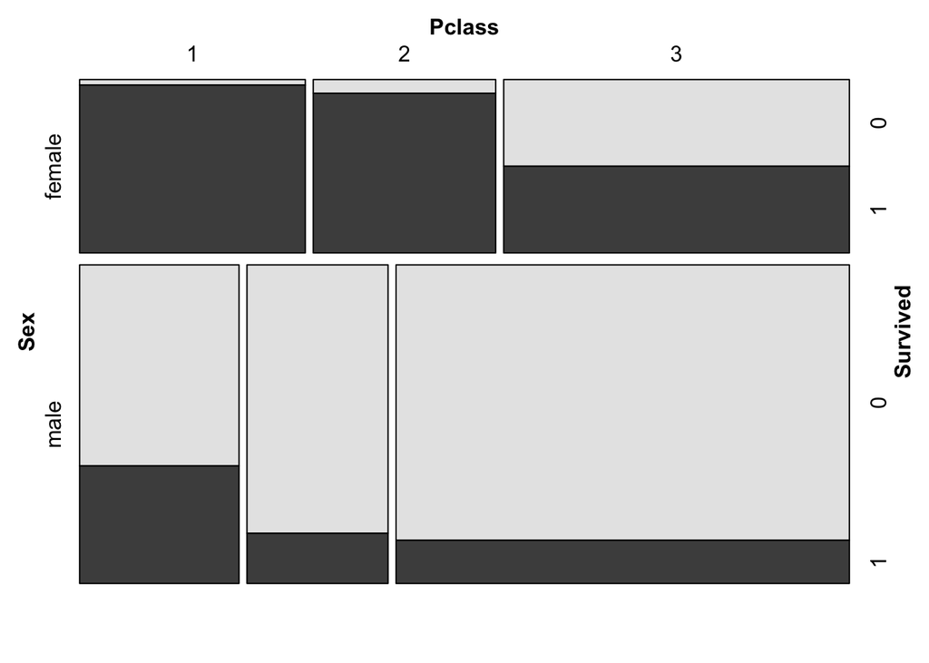

```r
## mosaicplot( Survived ~ Sex + Pclass, titanic_train )
library(vcd)
mosaic( Survived ~ Sex + Pclass, titanic_train )
```

## Contingency values

1. First we find the passenger counts:

```r
pCountsDF <- xtabs( ~ Sex + Pclass, titanic_train )
pCountsDF
```

```
##         Pclass
## Sex        1   2   3
##   female  94  76 144
##   male   122 108 347
```

2. Then we find the total of passenger ages:

```r
pTotalAgesDF <- xtabs( Age ~ Sex + Pclass, titanic_train )
pTotalAgesDF
```

```
##         Pclass
## Sex            1       2       3
##   female 2942.00 2125.50 2218.50
##   male   4169.42 3043.33 6706.42
```

3. Finally we divide the total ages data frame by the counts data frame:

```r
pTotalAgesDF / pCountsDF
```

```
##         Pclass
## Sex             1        2        3
##   female 31.29787 27.96711 15.40625
##   male   34.17557 28.17898 19.32686
```

## Distributions plots

It is a good idea to get an impression of the numerical variables distributions in a given dataset.

There are several approaches for doing this (in R and in general.)

### Using base functions

First we can simply use the base function `boxplot`, e.g. `boxplot( attitude )`. In the command below the function `boxplot` rotates and prints all column names by the argument `las=2` and uses alternating coloring by the argument `col=...`.

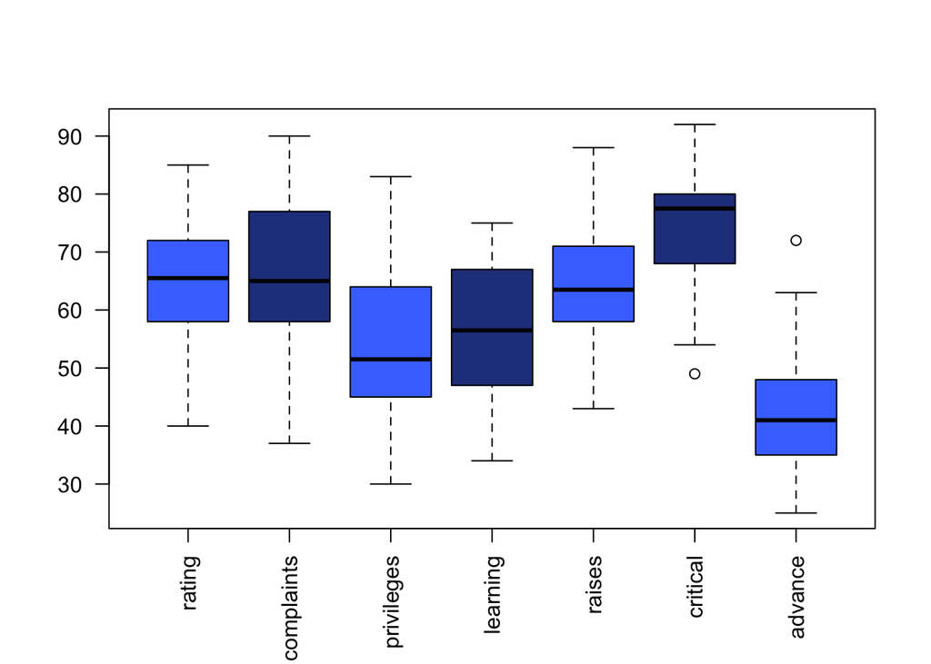

```r
boxplot( attitude, las=2, col = c("royalblue1","royalblue4") )
```

Alternatively, we can plot a histograms for all numerical columns.

### Using the package “lattice”

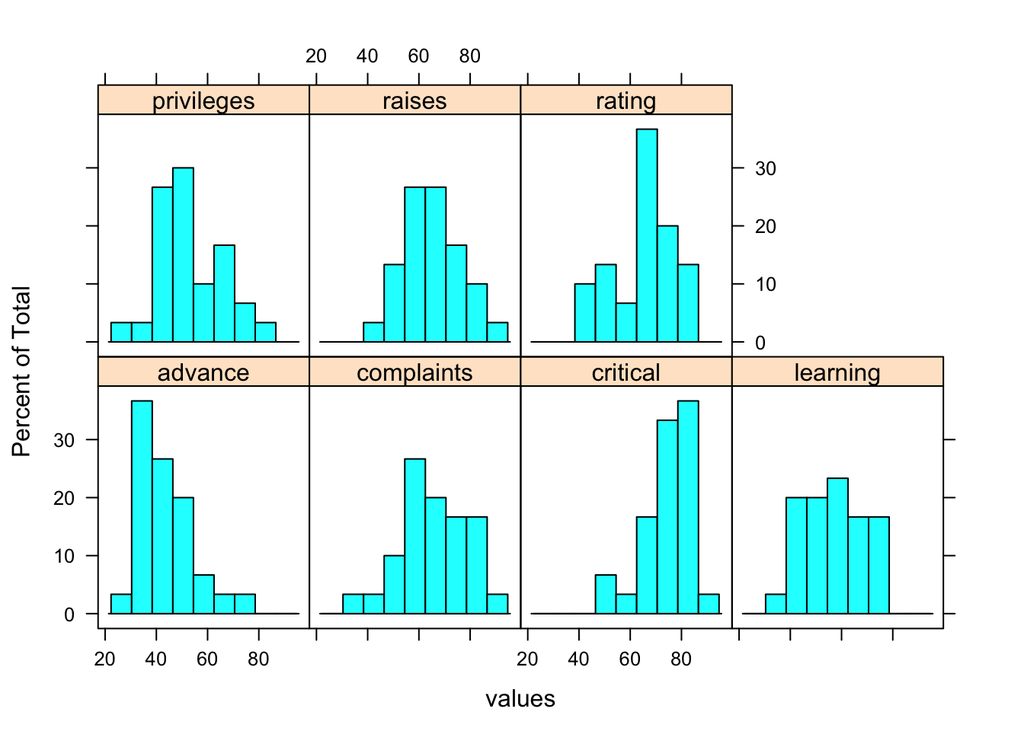

```r
library(lattice)
histogram( ~ values | ind, stack(attitude) )
```

### Using the package “ggplot2”

Let us get fencier. Note that is this a much harder to specify plot compared to the one made with “lattice” above.

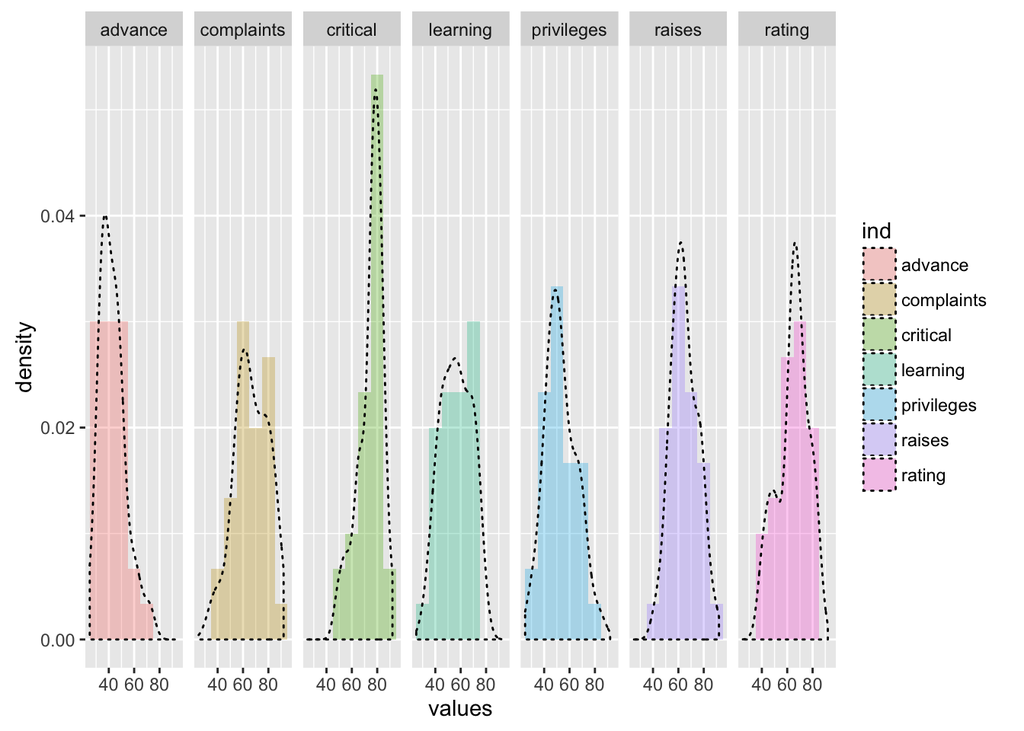

```r
library(ggplot2)
ggplot(stack(attitude)) + aes( x = values, fill = ind ) +
  geom_histogram( aes(y = ..density..), binwidth=10, alpha = 0.3) +
  geom_density(alpha = 0,linetype=3) +
  facet_grid( . ~ ind)
```

## Cross correllations plots

It useful to visualize scatter plots made by pairs of numerical variables in a dataset. This can be easily (readily) done with the function `pairs`:

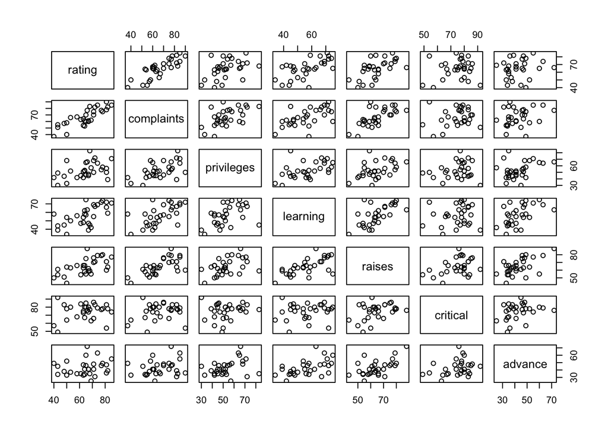

```r
pairs(attitude)
```

Prettier and more informative plots can be obtained with other, non-base package functions.

### Using the package “GGally” based on “ggplot2”

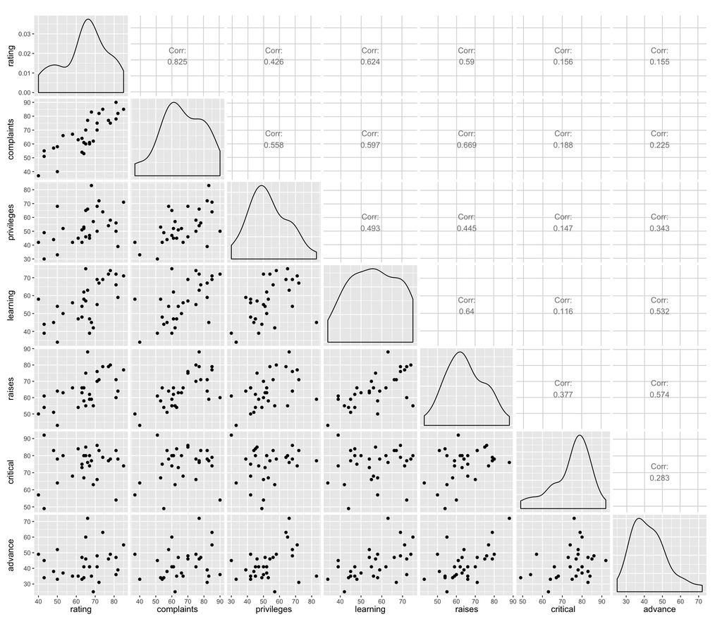

```r
library(GGally)
ggpairs(attitude)
```

For more details and related plots see [“ggcorr: correlation matrixes with ggplot2”](https://briatte.github.io/ggcorr/).